# 라이브러리 및 데이터 불러오기

## 라이브러리

```python
wd = '/home/pirl/BDAI-정덕성/Big_Data/data/'

import pandas as pd
import numpy as np
import matplotlib
import matplotlib.pyplot as plt
import seaborn as sns

# 데이터 분할
from sklearn.model_selection import train_test_split

# 데이터 전처리: 표준화, 날짜/시간
from sklearn.preprocessing import StandardScaler
from datetime import datetime

# 예측 모형: 로지스틱 회귀분석(Logit), 의사결정나무(DTC), 랜덤포레스트(RFC), 그래디언트부스팅(GBC)
from statsmodels.api import Logit
from sklearn.tree import DecisionTreeClassifier as DTC
from sklearn.ensemble import RandomForestClassifier as RFC
from sklearn.ensemble import GradientBoostingClassifier as GBC
from sklearn.svm import SVC
from sklearn.model_selection import GridSearchCV

# 평가 함수
from sklearn.metrics import f1_score, roc_curve, auc
from sklearn.metrics import accuracy_score
from sklearn.metrics import confusion_matrix

# 검정
from statsmodels.stats.proportion import proportions_ztest

# 나무
from sklearn.tree import export_graphviz
import graphviz

%matplotlib inline
matplotlib.rc('font', family = 'NanumBarunGothic')
```

## 함수 정의

```python
# Two-way tab
def func_cross_tab(y_data, x_data, var):
    print()
    print(pd.crosstab(index=y_data, columns=x_data[var]))
    print()
    print(pd.crosstab(index=y_data, columns=x_data[var], normalize="columns").round(3))
    print()
```

## 데이터 불러오기

```python
file = wd + 'SCALE불량.csv'
df_raw = pd.read_csv(file, engine='python', encoding='euc-kr')
df_raw.info()
```

```
<class 'pandas.core.frame.DataFrame'>
RangeIndex: 720 entries, 0 to 719
Data columns (total 21 columns):
PLATE_NO             720 non-null object
ROLLING_DATE         720 non-null object
SCALE                720 non-null object
SPEC                 720 non-null object
STEEL_KIND           720 non-null object
PT_THK               720 non-null float64
PT_WDTH              720 non-null int64
PT_LTH               720 non-null int64
PT_WGT               720 non-null int64
FUR_NO               720 non-null object
FUR_NO_ROW           720 non-null int64
FUR_HZ_TEMP          720 non-null int64
FUR_HZ_TIME          720 non-null int64
FUR_SZ_TEMP          720 non-null int64
FUR_SZ_TIME          720 non-null int64
FUR_TIME             720 non-null int64
FUR_EXTEMP           720 non-null int64
ROLLING_TEMP_T5      720 non-null int64
HSB                  720 non-null object
ROLLING_DESCALING    720 non-null int64
WORK_GR              720 non-null object
dtypes: float64(1), int64(12), object(8)
memory usage: 118.2+ KB
```

## 데이터 변형

### ID형 변수 제거(PLATE_NO, ROLLING_DATE)

- 본 분석에서는 제품 ID와 생산 시각 정보를 사용하지 않으므로 두 변수 제거

```python
df_raw.drop(['PLATE_NO', 'ROLLING_DATE'], axis = 1, inplace = True)
```

```python
df_raw.info()
```

```
<class 'pandas.core.frame.DataFrame'>
RangeIndex: 720 entries, 0 to 719
Data columns (total 19 columns):
SCALE                720 non-null object
SPEC                 720 non-null object
STEEL_KIND           720 non-null object
PT_THK               720 non-null float64
PT_WDTH              720 non-null int64
PT_LTH               720 non-null int64
PT_WGT               720 non-null int64
FUR_NO               720 non-null object
FUR_NO_ROW           720 non-null int64
FUR_HZ_TEMP          720 non-null int64
FUR_HZ_TIME          720 non-null int64
FUR_SZ_TEMP          720 non-null int64
FUR_SZ_TIME          720 non-null int64
FUR_TIME             720 non-null int64
FUR_EXTEMP           720 non-null int64
ROLLING_TEMP_T5      720 non-null int64
HSB                  720 non-null object
ROLLING_DESCALING    720 non-null int64
WORK_GR              720 non-null object
dtypes: float64(1), int64(12), object(6)
memory usage: 107.0+ KB
```

### 주요 이상 변수 검토

- 균열대 온도, 압연온도 동일
- 가열대 온도(ROLLING_TEMP_T5) 결측치 6개 제거

```python
# FUR_EXTEMP, FUR_SZ_TEMP 동일 변수 -> FUR_EXTEMP 제거
df_raw.drop('FUR_EXTEMP', axis=1, inplace=True)
df_raw.describe().round(3)
```

|  | PT_THK | PT_WDTH | PT_LTH | PT_WGT | FUR_NO_ROW | FUR_HZ_TEMP | FUR_HZ_TIME | FUR_SZ_TEMP | FUR_SZ_TIME | FUR_TIME | ROLLING_TEMP_T5 | ROLLING_DESCALING |
| --- | --- | --- | --- | --- | --- | --- | --- | --- | --- | --- | --- | --- |
| count | 720.000 | 720.000 | 720.000 | 720.000 | 720.000 | 720.000 | 720.000 | 720.000 | 720.000 | 720.000 | 720.000 | 720.000 |
| mean | 29.268 | 2807.128 | 34323.269 | 41481.778 | 1.497 | 1155.339 | 88.528 | 1149.667 | 78.803 | 300.564 | 933.921 | 8.319 |
| std | 19.153 | 517.840 | 13828.435 | 24751.322 | 0.500 | 20.866 | 37.661 | 17.572 | 36.421 | 45.390 | 107.864 | 1.623 |
| min | 12.030 | 1800.000 | 7893.000 | 7820.000 | 1.000 | 1103.000 | 43.000 | 1113.000 | 35.000 | 221.000 | 0.000 | 5.000 |
| 25% | 16.090 | 2466.000 | 22663.000 | 17757.500 | 1.000 | 1139.000 | 65.000 | 1132.000 | 57.750 | 257.000 | 889.750 | 6.000 |
| 50% | 20.130 | 2725.000 | 37380.000 | 36120.000 | 1.000 | 1158.000 | 75.000 | 1155.000 | 67.500 | 304.000 | 951.000 | 8.000 |
| 75% | 40.000 | 3125.000 | 43735.000 | 61120.000 | 2.000 | 1171.000 | 101.000 | 1164.000 | 86.000 | 342.000 | 994.250 | 10.000 |
| max | 100.340 | 4575.000 | 54917.000 | 115080.000 | 2.000 | 1206.000 | 312.000 | 1185.000 | 294.000 | 398.000 | 1078.000 | 10.000 |

```python
df_raw['ROLLING_TEMP_T5'].sort_values(ascending=True).head(10)
```

```
496      0
495      0
494      0
184      0
185      0
41       0
519    723
448    745
77     760
74     773
Name: ROLLING_TEMP_T5, dtype: int64
```

```python
# 가열대 온도(ROLLING_TEMP_T5) = 0인 관측치 6개 제거
df_raw = df_raw.query('ROLLING_TEMP_T5!=0')
df_raw['ROLLING_TEMP_T5'].sort_values(ascending=True).head(10)
```

```
519    723
448    745
77     760
74     773
431    802
432    805
44     808
514    811
513    811
500    812
Name: ROLLING_TEMP_T5, dtype: int64
```

### 범주형 변수 검토

- 강종 C, T로 분류

```python
# 가열로 순번: 범주형으로 처리
df_raw['FUR_NO_ROW'] = df_raw['FUR_NO_ROW'].astype('object')

# 작업시간: datetime형으로 처리
#         strftime to parse time, eg "%d/%m/%Y", note that "%f" will parse
# df_raw['ROLLING_DATE'] = df_raw.ROLLING_DATE.apply(str)

# 작업조(WORK_GR) object형으로 처리
df_raw['WORK_GR'] = df_raw['WORK_GR'].astype('object')
```

#### 품종(SPEC)

```python
df_raw['SPEC'].unique()
```

```
array(['AB/EH32-TM', 'NV-E36-TM', 'BV-EH36-TM', 'COMMON', 'GL-E32-TM',
       'GL-E36-TM', 'AB/EH36-TM', 'KS-HSB600', 'LR-EH36-TM', 'BV-B',
       'LR-B', 'JS-SM490YB', 'LR-A', 'JS-SM490A', 'KS-SM400B',
       'JS-SM400B', 'AB/B', 'KS-SS400', 'KR-A', 'NV-A', 'JS-SS400',
       'KS-SM400A', 'KS-SM490B', 'V42JBN3', 'BV-AH32', 'JS-SM490YA',
       'AB/AH32', 'LR-AH32', 'NV-B', 'NV-A32', 'KS-SM490A', 'NK-KA32',
       'GL-A32', 'AB/A', 'LR-AH36', 'A709-36', 'KR-AH32', 'A516-60',
       'NV-D36-TM', 'NK-KA32-TM', 'GL-A32-TM', 'LR-AH36-TM', 'NV-E32-TM',
       'KS-HSB500', 'API-2W-50T', 'GL-A36-TM', 'BV-EH32-TM', 'NV-A32-TM',
       'NV-D32-TM', 'NK-KD36-TM', 'GL-D36-TM', 'PILAC-BT33', 'BV-AH32-TM',
       'BV-AH36-TM', 'NV-A36-TM', 'BV-AH36-TL', 'BV-A', 'GL-A', 'NK-KA',
       'CCS-B', 'A283-C', 'SA283-C', 'JS-SM400A'], dtype=object)
```

```python
len(df_raw['SPEC'].unique())
```

```
63
```

```python
# 품종 단순화
spec_abs = [0] * df_raw.shape[0]
for i in range(df_raw["SPEC"].count()):
    code = str(df_raw.iloc[i, 1])[0:3]
    code = code.replace("/", "")
    code = code.replace("-", "")
    spec_abs[i] = code
df_raw["SPEC_ABS"] = spec_abs

# 품종 19개
len(df_raw['SPEC_ABS'].unique())
```

```
19
```

#### 강종(STEEL_KIND)

- C계열과 T계열로 구분

```python
# 강종 9개
len(df_raw['STEEL_KIND'].unique())
```

```
9
```

```python
val_list = df_raw['STEEL_KIND'].unique()
idx = pd.Index(df_raw['STEEL_KIND'])
idx.value_counts()
```

```
C0    501
T8     94
T5     41
T7     35
T1     18
T0     15
C3      7
T3      2
C1      1
Name: STEEL_KIND, dtype: int64
```

```python
df_raw.info()
```

```
<class 'pandas.core.frame.DataFrame'>
Int64Index: 714 entries, 0 to 719
Data columns (total 19 columns):
SCALE                714 non-null object
SPEC                 714 non-null object
STEEL_KIND           714 non-null object
PT_THK               714 non-null float64
PT_WDTH              714 non-null int64
PT_LTH               714 non-null int64
PT_WGT               714 non-null int64
FUR_NO               714 non-null object
FUR_NO_ROW           714 non-null object
FUR_HZ_TEMP          714 non-null int64
FUR_HZ_TIME          714 non-null int64
FUR_SZ_TEMP          714 non-null int64
FUR_SZ_TIME          714 non-null int64
FUR_TIME             714 non-null int64
ROLLING_TEMP_T5      714 non-null int64
HSB                  714 non-null object
ROLLING_DESCALING    714 non-null int64
WORK_GR              714 non-null object
SPEC_ABS             714 non-null object
dtypes: float64(1), int64(10), object(8)
memory usage: 131.6+ KB
```

```python
steel_abs = [0] * df_raw.shape[0]
for i in range(df_raw["STEEL_KIND"].count()):
    steel_abs[i] = str(df_raw.iloc[i, 2])[0]
df_raw["STEEL_ABS"] = steel_abs

# C 계열과 T 계열로 수정
len(df_raw['STEEL_ABS'].unique())
```

```
2
```

#### HSB 적용

- HSB는 공정상 중요한 절차이나, 본 자료의 경우 HSB를 적용하지 않은 모든 표본에 결함 발생
- 즉 HSB를 적용하지 않은 표본에 한하여, HSB 적용 여부는 결함 발생 여부에 대한 확률적인 정보를 갖고 있지 않음.
- 따라서 HSB를 적용하지 않은 표본을 제거하고, 해당 변수 또한 제거함

```python
func_cross_tab(df_raw['SCALE'], df_raw, 'HSB')
```

```
HSB    미적용   적용
SCALE
불량      33  198
양품       0  483

HSB    미적용     적용
SCALE
불량     1.0  0.291
양품     0.0  0.709
```

```python
df_raw = df_raw.query('HSB=="적용"')
func_cross_tab(df_raw['SCALE'], df_raw, 'HSB')
```

```
HSB     적용
SCALE
불량     198
양품     483

HSB       적용
SCALE
불량     0.291
양품     0.709
```

```python
df_raw['SCALE'].value_counts(normalize = True)
```

```
양품    0.709251
불량    0.290749
Name: SCALE, dtype: float64
```

```python
df_raw.drop('HSB', axis = 1, inplace = True)
```

```python
df_raw.info()
```

```
<class 'pandas.core.frame.DataFrame'>
Int64Index: 681 entries, 0 to 719
Data columns (total 19 columns):
SCALE                681 non-null object
SPEC                 681 non-null object
STEEL_KIND           681 non-null object
PT_THK               681 non-null float64
PT_WDTH              681 non-null int64
PT_LTH               681 non-null int64
PT_WGT               681 non-null int64
FUR_NO               681 non-null object
FUR_NO_ROW           681 non-null object
FUR_HZ_TEMP          681 non-null int64
FUR_HZ_TIME          681 non-null int64
FUR_SZ_TEMP          681 non-null int64
FUR_SZ_TIME          681 non-null int64
FUR_TIME             681 non-null int64
ROLLING_TEMP_T5      681 non-null int64
ROLLING_DESCALING    681 non-null int64
WORK_GR              681 non-null object
SPEC_ABS             681 non-null object
STEEL_ABS            681 non-null object
dtypes: float64(1), int64(10), object(8)
memory usage: 106.4+ KB
```

```python
df_raw['WORK_GR'].unique()
```

```
array(['2조', '3조', '1조', '4조'], dtype=object)
```

```python
df_raw['FUR_NO'].unique()
```

```
array(['1호기', '2호기', '3호기'], dtype=object)
```

### 더미 변수

```python
df_dummy_x = df_raw.drop(['SPEC', 'STEEL_KIND', 'SCALE'], axis=1)
df_dummy_x = pd.get_dummies(df_dummy_x)
df_dummy_x.info()
```

```
<class 'pandas.core.frame.DataFrame'>
Int64Index: 681 entries, 0 to 719
Data columns (total 40 columns):
PT_THK               681 non-null float64
PT_WDTH              681 non-null int64
PT_LTH               681 non-null int64
PT_WGT               681 non-null int64
FUR_HZ_TEMP          681 non-null int64
FUR_HZ_TIME          681 non-null int64
FUR_SZ_TEMP          681 non-null int64
FUR_SZ_TIME          681 non-null int64
FUR_TIME             681 non-null int64
ROLLING_TEMP_T5      681 non-null int64
ROLLING_DESCALING    681 non-null int64
FUR_NO_1호기           681 non-null uint8
FUR_NO_2호기           681 non-null uint8
FUR_NO_3호기           681 non-null uint8
FUR_NO_ROW_1         681 non-null uint8
FUR_NO_ROW_2         681 non-null uint8
WORK_GR_1조           681 non-null uint8
WORK_GR_2조           681 non-null uint8
WORK_GR_3조           681 non-null uint8
WORK_GR_4조           681 non-null uint8
SPEC_ABS_A28         681 non-null uint8
SPEC_ABS_A51         681 non-null uint8
SPEC_ABS_A70         681 non-null uint8
SPEC_ABS_AB          681 non-null uint8
SPEC_ABS_API         681 non-null uint8
SPEC_ABS_BV          681 non-null uint8
SPEC_ABS_CCS         681 non-null uint8
SPEC_ABS_COM         681 non-null uint8
SPEC_ABS_GL          681 non-null uint8
SPEC_ABS_JS          681 non-null uint8
SPEC_ABS_KR          681 non-null uint8
SPEC_ABS_KS          681 non-null uint8
SPEC_ABS_LR          681 non-null uint8
SPEC_ABS_NK          681 non-null uint8
SPEC_ABS_NV          681 non-null uint8
SPEC_ABS_PIL         681 non-null uint8
SPEC_ABS_SA2         681 non-null uint8
SPEC_ABS_V42         681 non-null uint8
STEEL_ABS_C          681 non-null uint8
STEEL_ABS_T          681 non-null uint8
dtypes: float64(1), int64(10), uint8(29)
memory usage: 83.1 KB
```

# EDA

## 기술통계량

```python
df_raw.describe().round(3)
```

|  | PT_THK | PT_WDTH | PT_LTH | PT_WGT | FUR_HZ_TEMP | FUR_HZ_TIME | FUR_SZ_TEMP | FUR_SZ_TIME | FUR_TIME | ROLLING_TEMP_T5 | ROLLING_DESCALING |
| --- | --- | --- | --- | --- | --- | --- | --- | --- | --- | --- | --- |
| count | 681.000 | 681.000 | 681.000 | 681.000 | 681.000 | 681.000 | 681.000 | 681.000 | 681.000 | 681.000 | 681.000 |
| mean | 29.026 | 2805.223 | 34352.269 | 41631.013 | 1155.301 | 88.636 | 1149.630 | 78.843 | 300.189 | 942.311 | 8.317 |
| std | 18.745 | 515.657 | 13749.316 | 24901.759 | 20.796 | 37.590 | 17.474 | 36.634 | 45.106 | 66.127 | 1.612 |
| min | 12.030 | 1800.000 | 7893.000 | 7820.000 | 1103.000 | 43.000 | 1113.000 | 35.000 | 221.000 | 723.000 | 5.000 |
| 25% | 16.090 | 2466.000 | 22663.000 | 17770.000 | 1139.000 | 65.000 | 1133.000 | 57.000 | 257.000 | 891.000 | 7.000 |
| 50% | 20.130 | 2725.000 | 37380.000 | 36120.000 | 1158.000 | 75.000 | 1155.000 | 68.000 | 304.000 | 953.000 | 8.000 |
| 75% | 38.430 | 3125.000 | 43728.000 | 61120.000 | 1171.000 | 101.000 | 1164.000 | 86.000 | 342.000 | 996.000 | 10.000 |
| max | 100.340 | 4575.000 | 54917.000 | 115080.000 | 1206.000 | 312.000 | 1185.000 | 294.000 | 398.000 | 1078.000 | 10.000 |

```python
df_dummy_x.describe()
```

[output not shown]

8 rows × 40 columns

```python
# 양품 표본
df_raw.query('SCALE=="양품"').describe().round(3)
```

|  | PT_THK | PT_WDTH | PT_LTH | PT_WGT | FUR_HZ_TEMP | FUR_HZ_TIME | FUR_SZ_TEMP | FUR_SZ_TIME | FUR_TIME | ROLLING_TEMP_T5 | ROLLING_DESCALING |
| --- | --- | --- | --- | --- | --- | --- | --- | --- | --- | --- | --- |
| count | 483.000 | 483.000 | 483.000 | 483.000 | 483.000 | 483.000 | 483.000 | 483.000 | 483.000 | 483.000 | 483.000 |
| mean | 30.695 | 2885.389 | 33476.511 | 37752.919 | 1151.923 | 87.110 | 1145.246 | 85.027 | 301.555 | 916.648 | 8.340 |
| std | 20.655 | 505.356 | 15216.561 | 24102.488 | 21.072 | 34.261 | 17.716 | 40.965 | 47.293 | 56.719 | 1.729 |
| min | 12.030 | 1800.000 | 7893.000 | 7820.000 | 1103.000 | 43.000 | 1113.000 | 40.000 | 224.000 | 723.000 | 6.000 |
| 25% | 15.080 | 2512.500 | 17112.500 | 15690.000 | 1135.000 | 64.500 | 1127.500 | 59.000 | 255.000 | 875.000 | 6.000 |
| 50% | 20.130 | 2880.000 | 37198.000 | 32420.000 | 1151.000 | 73.000 | 1147.000 | 71.000 | 308.000 | 926.000 | 8.000 |
| 75% | 40.350 | 3166.000 | 47657.000 | 51680.000 | 1169.000 | 106.000 | 1161.500 | 95.000 | 342.000 | 965.000 | 10.000 |
| max | 89.630 | 4575.000 | 54917.000 | 115080.000 | 1200.000 | 312.000 | 1175.000 | 294.000 | 398.000 | 1000.000 | 10.000 |

```python
# 양품 표본
df_raw.query('SCALE=="불량"').describe().round(3)
```

|  | PT_THK | PT_WDTH | PT_LTH | PT_WGT | FUR_HZ_TEMP | FUR_HZ_TIME | FUR_SZ_TEMP | FUR_SZ_TIME | FUR_TIME | ROLLING_TEMP_T5 | ROLLING_DESCALING |
| --- | --- | --- | --- | --- | --- | --- | --- | --- | --- | --- | --- |
| count | 198.000 | 198.000 | 198.000 | 198.000 | 198.00 | 198.000 | 198.000 | 198.000 | 198.000 | 198.000 | 198.000 |
| mean | 24.955 | 2609.667 | 36488.586 | 51091.212 | 1163.54 | 92.359 | 1160.323 | 63.758 | 296.859 | 1004.914 | 8.263 |
| std | 12.068 | 488.661 | 8919.140 | 24336.259 | 17.61 | 44.563 | 11.136 | 14.279 | 39.178 | 40.853 | 1.287 |
| min | 12.550 | 1929.000 | 9547.000 | 13460.000 | 1115.00 | 46.000 | 1119.000 | 35.000 | 221.000 | 812.000 | 5.000 |
| 25% | 19.100 | 2288.000 | 30730.000 | 33260.000 | 1154.00 | 67.000 | 1154.250 | 54.000 | 261.000 | 1001.250 | 8.000 |
| 50% | 20.140 | 2495.500 | 37648.000 | 42870.000 | 1164.00 | 77.000 | 1161.500 | 61.000 | 298.500 | 1013.000 | 8.000 |
| 75% | 30.130 | 2701.750 | 42729.250 | 69137.500 | 1172.00 | 96.750 | 1166.000 | 70.750 | 330.000 | 1029.000 | 9.000 |
| max | 100.340 | 4528.000 | 54258.000 | 111200.000 | 1206.00 | 251.000 | 1185.000 | 134.000 | 395.000 | 1078.000 | 10.000 |

## 산점도 (연속변수)

- 연속변수 간 산점도 파악
- 이상치 파악

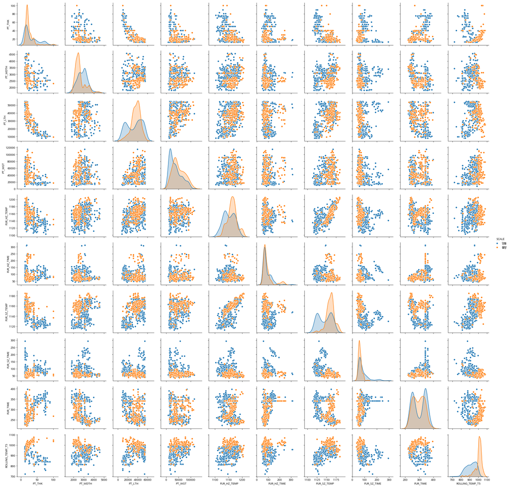

```python
df_cont = df_raw.select_dtypes(exclude='object').drop('ROLLING_DESCALING', axis=1)
df_cont['SCALE'] = df_raw['SCALE']
sns.pairplot(df_cont, hue='SCALE')
```

## 양품/불량별 설명변수 중심척도 비교

### 연속변수

```python
# PT
cols_cont = df_cont.columns
plot_list = [0] * len(cols_cont)

df_grouped = df_raw.groupby('SCALE').mean()
df_grouped.round(3)
```

| SCALE | PT_THK | PT_WDTH | PT_LTH | PT_WGT | FUR_HZ_TEMP | FUR_HZ_TIME | FUR_SZ_TEMP | FUR_SZ_TIME | FUR_TIME | ROLLING_TEMP_T5 | ROLLING_DESCALING |
| --- | --- | --- | --- | --- | --- | --- | --- | --- | --- | --- | --- |
| 불량 | 24.955 | 2609.667 | 36488.586 | 51091.212 | 1163.540 | 92.359 | 1160.323 | 63.758 | 296.859 | 1004.914 | 8.263 |
| 양품 | 30.695 | 2885.389 | 33476.511 | 37752.919 | 1151.923 | 87.110 | 1145.246 | 85.027 | 301.555 | 916.648 | 8.340 |

```python
# scaled to 100 for 양품 means
for col in df_grouped.columns:
    df_grouped[col][0] = 100 * (df_grouped[col][0] / df_grouped[col][1] )
df_grouped.round(3)
```

| SCALE | PT_THK | PT_WDTH | PT_LTH | PT_WGT | FUR_HZ_TEMP | FUR_HZ_TIME | FUR_SZ_TEMP | FUR_SZ_TIME | FUR_TIME | ROLLING_TEMP_T5 | ROLLING_DESCALING |
| --- | --- | --- | --- | --- | --- | --- | --- | --- | --- | --- | --- |
| 불량 | 81.301 | 90.444 | 108.998 | 135.330 | 101.008 | 106.026 | 101.316 | 74.985 | 98.443 | 109.629 | 99.078 |
| 양품 | 30.695 | 2885.389 | 33476.511 | 37752.919 | 1151.923 | 87.110 | 1145.246 | 85.027 | 301.555 | 916.648 | 8.340 |

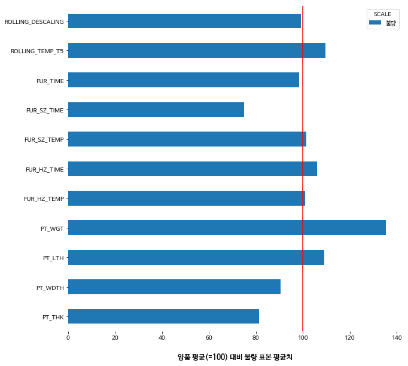

```python
df = df_grouped.query('SCALE=="불량"')
df = df.T
ax = df.plot(kind='barh', figsize=(10,10))

# despine
ax.spines['right'].set_visible(False)
ax.spines['top'].set_visible(False)
ax.spines['left'].set_visible(False)
ax.spines['bottom'].set_visible(False)

# Draw vertical axis lines
ax.axvline(x=100, color='red', zorder=1)

# Set x-axis label
ax.set_xlabel('양품 평균(=100) 대비 불량 표본 평균치', labelpad=20, weight='bold', size=12)
```

## 양품/불량별 평균 검정(Two-sample t-test)

```python
from scipy.stats import ttest_ind

# Two-sample t-test: 양품 vs 불량
t_stat = []; p_val = []
for col in df_grouped.columns:
    a = df_raw[df_raw['SCALE']=='양품']
    b = df_raw[df_raw['SCALE']=='불량']
    t, p = ttest_ind(a[col], b[col])
    t_stat.append(t)
    p_val.append(p)
```

```python
df_ttest = pd.DataFrame({'t-stat': t_stat, 'p-value': p_val}, index = cols_cont)
df_ttest.sort_values('t-stat', ascending=False).round(3)
```

|  | t-stat | p-value |
| --- | --- | --- |
| FUR_SZ_TIME | 7.128 | 0.000 |
| PT_WDTH | 6.527 | 0.000 |
| PT_THK | 3.661 | 0.000 |
| FUR_TIME | 1.234 | 0.218 |
| SCALE | 0.565 | 0.572 |
| FUR_HZ_TIME | -1.657 | 0.098 |
| PT_LTH | -2.607 | 0.009 |
| PT_WGT | -6.540 | 0.000 |
| FUR_HZ_TEMP | -6.839 | 0.000 |
| FUR_SZ_TEMP | -11.107 | 0.000 |
| ROLLING_TEMP_T5 | -19.882 | 0.000 |

# 분류 모형을 통한 영향 요인 분석

## Train/Valid/Test 분리

```python
df_raw_x = df_dummy_x
df_raw_y = np.where(df_raw['SCALE']=='불량', 0, 1)


df_train_x, df_test_x, df_train_y, df_test_y = train_test_split(df_raw_x, df_raw_y, test_size = 0.3, random_state=1234)
df_train_x, df_valid_x, df_train_y, df_valid_y = train_test_split(df_train_x, df_train_y, test_size = (3/7), random_state=1234)

print('train data X size:{}'.format(df_train_x.shape))
print('train data Y size:{}'.format(df_train_y.shape))
print('validation data X size:{}'.format(df_valid_x.shape))
print('validation data Y size:{}'.format(df_valid_y.shape))
print('test data X size:{}'.format(df_test_x.shape))
print('test data Y size:{}'.format(df_test_y.shape))
```

```
train data X size:(272, 40)
train data Y size:(272,)
validation data X size:(204, 40)
validation data Y size:(204,)
test data X size:(205, 40)
test data Y size:(205,)
```

```python
df_raw_y = pd.DataFrame(df_raw_y)
```

### 모형 성능 비교

```python
model = ['RFC', 'GBC']

# 정분류율
train_acc = []; test_acc = []

# f1 Score
model_f1_score = []

# auc score
model_auc = []
```

## 랜덤 포레스트

```python
rf_uncustomized = RFC(random_state=1234, n_estimators=100)
rf_uncustomized.fit(df_train_x, df_train_y)
```

```
RandomForestClassifier(bootstrap=True, class_weight=None, criterion='gini',
            max_depth=None, max_features='auto', max_leaf_nodes=None,
            min_impurity_decrease=0.0, min_impurity_split=None,
            min_samples_leaf=1, min_samples_split=2,
            min_weight_fraction_leaf=0.0, n_estimators=100, n_jobs=None,
            oob_score=False, random_state=1234, verbose=0,
            warm_start=False)
```

```python
print('Accuracy on Training: {0:.3f}\n'.format(rf_uncustomized.score(df_train_x, df_train_y)))
print('Accuracy on Test: {0:.3f}\n'.format(rf_uncustomized.score(df_valid_x, df_valid_y)))
```

```
Accuracy on Training: 1.000

Accuracy on Test: 0.966
```

```python
rf_params = {'max_depth':'',
             'min_samples_leaf':'',
             'min_samples_split':'',
             'n_estimators':'100'}
```

### n_estimators

|  | N_Tree | TrainScore | TestScore |
| --- | --- | --- | --- |
| 0 | 40 | 1.0 | 0.961 |
| 1 | 41 | 1.0 | 0.961 |
| 2 | 42 | 1.0 | 0.966 |
| 3 | 43 | 1.0 | 0.966 |
| 4 | 44 | 1.0 | 0.966 |
| 5 | 45 | 1.0 | 0.966 |
| 6 | 46 | 1.0 | 0.966 |
| 7 | 47 | 1.0 | 0.966 |
| 8 | 48 | 1.0 | 0.966 |
| 9 | 49 | 1.0 | 0.966 |
| 10 | 50 | 1.0 | 0.966 |
| 11 | 51 | 1.0 | 0.966 |
| 12 | 52 | 1.0 | 0.966 |
| 13 | 53 | 1.0 | 0.966 |
| 14 | 54 | 1.0 | 0.966 |
| 15 | 55 | 1.0 | 0.966 |
| 16 | 56 | 1.0 | 0.966 |
| 17 | 57 | 1.0 | 0.966 |
| 18 | 58 | 1.0 | 0.966 |
| 19 | 59 | 1.0 | 0.966 |
| 20 | 60 | 1.0 | 0.966 |

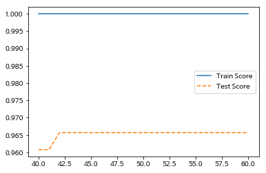

```python
# Train/Test Score 저장할 list
train_accuracy = []; test_accuracy = []

# max_depth
para_ntree = [ntree for ntree in range(40, 61)]


for v_max_ntree in para_ntree:
    rf = RFC(random_state=1234,
             n_estimators = v_max_ntree)
    rf.fit(df_train_x, df_train_y)
    train_accuracy.append(rf.score(df_train_x, df_train_y))
    test_accuracy.append(rf.score(df_valid_x, df_valid_y))


df_score_ntree = pd.DataFrame({'N_Tree': para_ntree,
                             'TrainScore': train_accuracy,
                             'TestScore': test_accuracy})

plt.plot(para_ntree, train_accuracy, linestyle='-', label="Train Score")
plt.plot(para_ntree, test_accuracy, linestyle='--', label="Test Score")
plt.legend()

df_score_ntree.round(3)
```

#### n_estimators = 42

```python
rf_params['n_estimators'] = 42
```

### min_samples_leaf

|  | leaf | TrainScore | TestScore |
| --- | --- | --- | --- |
| 0 | 1 | 1.000 | 0.966 |
| 1 | 2 | 0.993 | 0.961 |
| 2 | 3 | 0.985 | 0.946 |
| 3 | 4 | 0.967 | 0.941 |
| 14 | 15 | 0.919 | 0.936 |
| 10 | 11 | 0.923 | 0.936 |
| 7 | 8 | 0.930 | 0.926 |
| 9 | 10 | 0.926 | 0.926 |
| 11 | 12 | 0.930 | 0.926 |
| 17 | 18 | 0.915 | 0.922 |
| 15 | 16 | 0.919 | 0.922 |
| 13 | 14 | 0.919 | 0.922 |
| 12 | 13 | 0.923 | 0.922 |
| 8 | 9 | 0.930 | 0.922 |
| 6 | 7 | 0.930 | 0.922 |
| 5 | 6 | 0.934 | 0.922 |
| 4 | 5 | 0.956 | 0.922 |
| 16 | 17 | 0.915 | 0.912 |
| 18 | 19 | 0.912 | 0.912 |
| 24 | 25 | 0.912 | 0.912 |
| 19 | 20 | 0.912 | 0.907 |
| 20 | 21 | 0.908 | 0.907 |
| 21 | 22 | 0.908 | 0.907 |
| 22 | 23 | 0.908 | 0.907 |
| 23 | 24 | 0.901 | 0.902 |

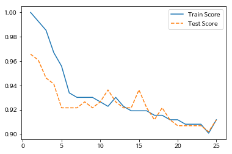

```python
# Train/Test Score 저장할 list
train_accuracy = []; test_accuracy = []

# max_leaf
para_leaf = [leaf for leaf in range(1, 26)]


for v_max_leaf in para_leaf:
    rf = RFC(random_state=1234,
             n_estimators = rf_params['n_estimators'],
             min_samples_leaf = v_max_leaf)
    rf.fit(df_train_x, df_train_y)
    train_accuracy.append(rf.score(df_train_x, df_train_y))
    test_accuracy.append(rf.score(df_valid_x, df_valid_y))


df_score_leaf = pd.DataFrame({'leaf': para_leaf,
                             'TrainScore': train_accuracy,
                             'TestScore': test_accuracy})

plt.plot(para_leaf, train_accuracy, linestyle='-', label="Train Score")
plt.plot(para_leaf, test_accuracy, linestyle='--', label="Test Score")
plt.legend()

df_score_leaf.sort_values('TestScore', ascending = False).round(3)
```

#### min_samples_leaf = 2

```python
rf_params['min_samples_leaf'] = 2
```

### min_samples_split

|  | MinsplitSize | TrainScore | TestScore |
| --- | --- | --- | --- |
| 0 | 4 | 0.993 | 0.961 |
| 1 | 6 | 0.989 | 0.956 |
| 12 | 28 | 0.945 | 0.956 |
| 6 | 16 | 0.971 | 0.951 |
| 15 | 34 | 0.938 | 0.951 |
| 14 | 32 | 0.938 | 0.951 |
| 2 | 8 | 0.985 | 0.951 |
| 5 | 14 | 0.974 | 0.946 |
| 23 | 50 | 0.930 | 0.946 |
| 8 | 20 | 0.963 | 0.946 |
| 9 | 22 | 0.967 | 0.946 |
| 11 | 26 | 0.949 | 0.946 |
| 4 | 12 | 0.974 | 0.946 |
| 3 | 10 | 0.982 | 0.946 |
| 16 | 36 | 0.945 | 0.946 |
| 7 | 18 | 0.974 | 0.946 |
| 10 | 24 | 0.949 | 0.941 |
| 13 | 30 | 0.938 | 0.941 |
| 24 | 52 | 0.926 | 0.941 |
| 17 | 38 | 0.949 | 0.936 |
| 25 | 54 | 0.923 | 0.931 |
| 27 | 58 | 0.919 | 0.931 |
| 28 | 60 | 0.923 | 0.931 |
| 21 | 46 | 0.926 | 0.926 |
| 18 | 40 | 0.941 | 0.926 |
| 26 | 56 | 0.923 | 0.922 |
| 20 | 44 | 0.934 | 0.917 |
| 19 | 42 | 0.930 | 0.917 |
| 22 | 48 | 0.930 | 0.912 |

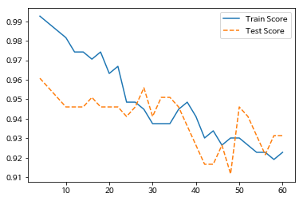

```python
# Train/Test Score 저장할 list
train_accuracy = []; test_accuracy = []

# max_depth
para_split = [split*2 for split in range(2, 31)]


for v_split in para_split:
    rf = RFC(random_state=1234,
             n_estimators = rf_params['n_estimators'],
             min_samples_leaf = rf_params['min_samples_leaf'],
             min_samples_split = v_split)
    rf.fit(df_train_x, df_train_y)
    train_accuracy.append(rf.score(df_train_x, df_train_y))
    test_accuracy.append(rf.score(df_valid_x, df_valid_y))


df_score_split = pd.DataFrame({'MinsplitSize': para_split,
                             'TrainScore': train_accuracy,
                             'TestScore': test_accuracy})


plt.plot(para_split, train_accuracy, linestyle='-', label="Train Score")
plt.plot(para_split, test_accuracy, linestyle='--', label="Test Score")
plt.legend()

df_score_split.sort_values('TestScore', ascending = False).round(3)
```

#### min_samples_split = 28

```python
rf_params['min_samples_split'] = 28
```

### max_depth

|  | MindepthSize | TrainScore | TestScore |
| --- | --- | --- | --- |
| 9 | 11 | 0.945 | 0.927 |
| 10 | 12 | 0.945 | 0.927 |
| 17 | 19 | 0.945 | 0.927 |
| 16 | 18 | 0.945 | 0.927 |
| 15 | 17 | 0.945 | 0.927 |
| 14 | 16 | 0.945 | 0.927 |
| 13 | 15 | 0.945 | 0.927 |
| 12 | 14 | 0.945 | 0.927 |
| 11 | 13 | 0.945 | 0.927 |
| 18 | 20 | 0.945 | 0.927 |
| 8 | 10 | 0.945 | 0.927 |
| 7 | 9 | 0.945 | 0.927 |
| 6 | 8 | 0.949 | 0.927 |
| 5 | 7 | 0.945 | 0.927 |
| 3 | 5 | 0.938 | 0.917 |
| 4 | 6 | 0.938 | 0.912 |
| 1 | 3 | 0.923 | 0.907 |
| 2 | 4 | 0.926 | 0.902 |
| 0 | 2 | 0.919 | 0.893 |

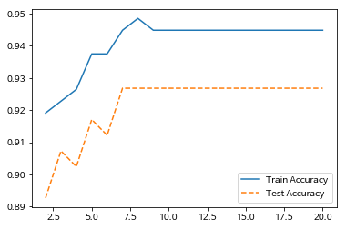

```python
# Train/Test Score 저장할 list
train_accuracy = []; test_accuracy = []

# max_depth
para_depth = [depth for depth in range(2, 21)]


for v_depth in para_depth:
    rf = RFC(random_state=1234,
             n_estimators = rf_params['n_estimators'],
             min_samples_leaf = rf_params['min_samples_leaf'],
             min_samples_split = rf_params['min_samples_split'],
             max_depth = v_depth)
    rf.fit(df_train_x, df_train_y)
    train_accuracy.append(rf.score(df_train_x, df_train_y))
    test_accuracy.append(rf.score(df_test_x, df_test_y))


df_score_depth = pd.DataFrame({'MindepthSize': para_depth,
                             'TrainScore': train_accuracy,
                             'TestScore': test_accuracy})


plt.plot(para_depth, train_accuracy, linestyle='-', label="Train Accuracy")
plt.plot(para_depth, test_accuracy, linestyle='--', label="Test Accuracy")
plt.legend()
df_score_depth.sort_values('TestScore', ascending=False).round(3)
```

#### max_depth = 7

```python
rf_params['max_depth'] = 7
```

### 랜덤 포레스트 최종 모형

```python
rf_final = RFC(random_state=1234,
               n_estimators = rf_params['n_estimators'],
               max_depth = rf_params['max_depth'],
               min_samples_leaf = rf_params['min_samples_leaf'],
               min_samples_split = rf_params['min_samples_split']
              )
rf_final.fit(df_train_x, df_train_y)
```

```
RandomForestClassifier(bootstrap=True, class_weight=None, criterion='gini',
            max_depth=7, max_features='auto', max_leaf_nodes=None,
            min_impurity_decrease=0.0, min_impurity_split=None,
            min_samples_leaf=2, min_samples_split=28,
            min_weight_fraction_leaf=0.0, n_estimators=42, n_jobs=None,
            oob_score=False, random_state=1234, verbose=0,
            warm_start=False)
```

```python
train_final = rf_final.score(df_train_x, df_train_y)
test_final = rf_final.score(df_test_x, df_test_y)
print('TrainScore: {:.3f}\nTestScore: {:.3f}'.format(train_final, test_final))
```

```
TrainScore: 0.945
TestScore: 0.927
```

```python
y_pred = rf_final.predict(df_test_x)
print('Accuracy: {0:.3f}\n'.format(accuracy_score(df_test_y, y_pred)))
print('Confusion Mat:\n{}'.format(confusion_matrix(df_test_y, y_pred)))
```

```
Accuracy: 0.927

Confusion Mat:
[[ 53  15]
 [  0 137]]
```

```python
v_feature_name = df_test_x.columns
df_importance = pd.DataFrame()
df_importance['Feature'] = v_feature_name
df_importance['Importance'] = rf_final.feature_importances_ # TREECLASS.feature_importances_

df_importance.sort_values('Importance', ascending=False, inplace=True)
df_importance.head(10).round(6)
```

[output not shown]

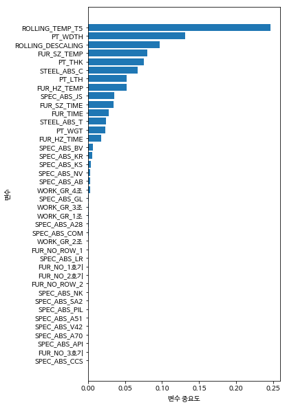

```python
plt.figure(figsize=(5,10))
df_importance.sort_values('Importance', ascending=True, inplace=True)
coordinates=range(len(df_importance))
plt.barh(y=coordinates, width=df_importance['Importance'])
plt.yticks(coordinates, df_importance['Feature'])
plt.xlabel('변수 중요도')
plt.ylabel('변수')
```

```python
# Train 정확도
train_acc.append(rf_final.score(df_train_x, df_train_y))

# Test 정확도
test_acc.append(rf_final.score(df_test_x, df_test_y))

# 예측값
y_pred = rf_final.predict(df_test_x)

# roc_curve, fpr
fpr, tpr, thresholds = roc_curve(df_test_y, y_pred)
roc_auc = auc(fpr, tpr)

# auc
model_auc.append(roc_auc)

# f1 score
model_f1_score.append(f1_score(df_test_y, y_pred))
```

## 그래디언트 부스팅

```python
gb_uncustomized = GBC(random_state=1234)
gb_uncustomized.fit(df_train_x, df_train_y)
```

```
GradientBoostingClassifier(criterion='friedman_mse', init=None,
              learning_rate=0.1, loss='deviance', max_depth=3,
              max_features=None, max_leaf_nodes=None,
              min_impurity_decrease=0.0, min_impurity_split=None,
              min_samples_leaf=1, min_samples_split=2,
              min_weight_fraction_leaf=0.0, n_estimators=100,
              n_iter_no_change=None, presort='auto', random_state=1234,
              subsample=1.0, tol=0.0001, validation_fraction=0.1,
              verbose=0, warm_start=False)
```

```python
print('Accuracy on Training: {0:.3f}\n'.format(gb_uncustomized.score(df_train_x, df_train_y)))
print('Accuracy on Test: {0:.3f}\n'.format(gb_uncustomized.score(df_valid_x, df_valid_y)))
```

```
Accuracy on Training: 1.000

Accuracy on Test: 0.980
```

```python
gb_uncustomized
```

```
GradientBoostingClassifier(criterion='friedman_mse', init=None,
              learning_rate=0.1, loss='deviance', max_depth=3,
              max_features=None, max_leaf_nodes=None,
              min_impurity_decrease=0.0, min_impurity_split=None,
              min_samples_leaf=1, min_samples_split=2,
              min_weight_fraction_leaf=0.0, n_estimators=100,
              n_iter_no_change=None, presort='auto', random_state=1234,
              subsample=1.0, tol=0.0001, validation_fraction=0.1,
              verbose=0, warm_start=False)
```

```python
gb_params = {'learning_rate':'',
          'max_depth':'',
          'min_samples_leaf':'',
          'min_samples_split':'',
          'n_estimators':''}
```

|  | L_Rate | TrainScore | TestScore |
| --- | --- | --- | --- |
| 2 | 0.3 | 1.0 | 0.985 |
| 0 | 0.1 | 1.0 | 0.980 |
| 1 | 0.2 | 1.0 | 0.980 |
| 3 | 0.4 | 1.0 | 0.971 |
| 4 | 0.5 | 1.0 | 0.971 |
| 5 | 0.6 | 1.0 | 0.971 |
| 6 | 0.7 | 1.0 | 0.971 |
| 8 | 0.9 | 1.0 | 0.961 |
| 7 | 0.8 | 1.0 | 0.941 |
| 9 | 1.0 | 1.0 | 0.941 |

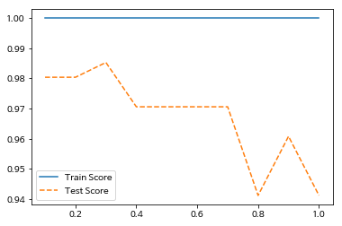

```python
# Train/Test Score 저장할 list
train_accuracy = []; test_accuracy = []

# max_depth
para_lrate = [lrate/10 for lrate in range(1, 11)]


for v_lrate in para_lrate:
    gb = GBC(random_state = 1234,
             learning_rate = v_lrate)
    gb.fit(df_train_x, df_train_y)
    train_accuracy.append(gb.score(df_train_x, df_train_y))
    test_accuracy.append(gb.score(df_valid_x, df_valid_y))


df_score_lrate = pd.DataFrame({'L_Rate': para_lrate,
                             'TrainScore': train_accuracy,
                             'TestScore': test_accuracy})

plt.plot(para_lrate, train_accuracy, linestyle='-', label="Train Score")
plt.plot(para_lrate, test_accuracy, linestyle='--', label="Test Score")
plt.legend()

df_score_lrate.sort_values('TestScore', ascending = False).round(3)
```

|  | L_Rate | TrainScore | TestScore |
| --- | --- | --- | --- |
| 15 | 0.35 | 1.0 | 0.990 |
| 2 | 0.22 | 1.0 | 0.990 |
| 8 | 0.28 | 1.0 | 0.990 |
| 16 | 0.36 | 1.0 | 0.990 |
| 10 | 0.30 | 1.0 | 0.985 |
| 19 | 0.39 | 1.0 | 0.985 |
| 5 | 0.25 | 1.0 | 0.985 |
| 7 | 0.27 | 1.0 | 0.985 |
| 9 | 0.29 | 1.0 | 0.985 |
| 1 | 0.21 | 1.0 | 0.985 |
| 11 | 0.31 | 1.0 | 0.985 |
| 13 | 0.33 | 1.0 | 0.985 |
| 14 | 0.34 | 1.0 | 0.985 |
| 18 | 0.38 | 1.0 | 0.980 |
| 17 | 0.37 | 1.0 | 0.980 |
| 0 | 0.20 | 1.0 | 0.980 |
| 12 | 0.32 | 1.0 | 0.980 |
| 6 | 0.26 | 1.0 | 0.980 |
| 4 | 0.24 | 1.0 | 0.980 |
| 3 | 0.23 | 1.0 | 0.980 |
| 20 | 0.40 | 1.0 | 0.971 |

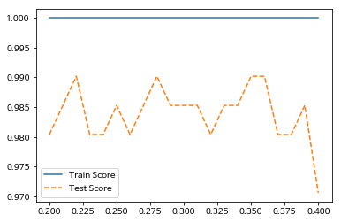

```python
# Train/Test Score 저장할 list
train_accuracy = []; test_accuracy = []

para_lrate = [lrate/100 for lrate in range(20, 41)]


for v_lrate in para_lrate:
    gb = GBC(random_state = 1234,
             learning_rate = v_lrate)
    gb.fit(df_train_x, df_train_y)
    train_accuracy.append(gb.score(df_train_x, df_train_y))
    test_accuracy.append(gb.score(df_valid_x, df_valid_y))


df_score_lrate = pd.DataFrame({'L_Rate': para_lrate,
                             'TrainScore': train_accuracy,
                             'TestScore': test_accuracy})

plt.plot(para_lrate, train_accuracy, linestyle='-', label="Train Score")
plt.plot(para_lrate, test_accuracy, linestyle='--', label="Test Score")
plt.legend()

df_score_lrate.sort_values('TestScore', ascending = False).round(3)
```

#### learning_rate = 0.35

```python
gb_params['learning_rate'] = 0.35
```

### n_estimators

|  | N_Tree | TrainScore | TestScore |
| --- | --- | --- | --- |
| 0 | 10 | 1.0 | 0.971 |
| 1 | 20 | 1.0 | 0.971 |
| 2 | 30 | 1.0 | 0.980 |
| 3 | 40 | 1.0 | 0.985 |
| 4 | 50 | 1.0 | 0.990 |
| 5 | 60 | 1.0 | 0.990 |
| 6 | 70 | 1.0 | 0.990 |
| 7 | 80 | 1.0 | 0.990 |
| 8 | 90 | 1.0 | 0.990 |
| 9 | 100 | 1.0 | 0.990 |
| 10 | 110 | 1.0 | 0.990 |
| 11 | 120 | 1.0 | 0.990 |
| 12 | 130 | 1.0 | 0.990 |
| 13 | 140 | 1.0 | 0.990 |
| 14 | 150 | 1.0 | 0.990 |

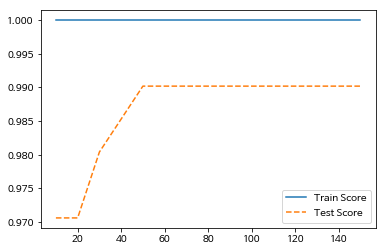

```python
# Train/Test Score 저장할 list
train_accuracy = []; test_accuracy = []

# max_depth
para_ntree = [ntree*10 for ntree in range(1, 16)]


for v_max_ntree in para_ntree:
    gb = GBC(random_state=1234,
             learning_rate = gb_params['learning_rate'],
             n_estimators = v_max_ntree)
    gb.fit(df_train_x, df_train_y)
    train_accuracy.append(gb.score(df_train_x, df_train_y))
    test_accuracy.append(gb.score(df_valid_x, df_valid_y))


df_score_ntree = pd.DataFrame({'N_Tree': para_ntree,
                             'TrainScore': train_accuracy,
                             'TestScore': test_accuracy})

plt.plot(para_ntree, train_accuracy, linestyle='-', label="Train Score")
plt.plot(para_ntree, test_accuracy, linestyle='--', label="Test Score")
plt.legend()

df_score_ntree.round(3)
```

#### n_estimators = 50

```python
gb_params['n_estimators'] = 50
```

### max_depth

|  | Depth | TrainScore | TestScore |
| --- | --- | --- | --- |
| 0 | 3 | 1.0 | 0.990 |
| 2 | 5 | 1.0 | 0.985 |
| 3 | 6 | 1.0 | 0.980 |
| 4 | 7 | 1.0 | 0.980 |
| 1 | 4 | 1.0 | 0.980 |
| 14 | 17 | 1.0 | 0.951 |
| 21 | 24 | 1.0 | 0.951 |
| 20 | 23 | 1.0 | 0.951 |
| 19 | 22 | 1.0 | 0.951 |
| 18 | 21 | 1.0 | 0.951 |
| 17 | 20 | 1.0 | 0.951 |
| 16 | 19 | 1.0 | 0.951 |
| 15 | 18 | 1.0 | 0.951 |
| 11 | 14 | 1.0 | 0.951 |
| 13 | 16 | 1.0 | 0.951 |
| 12 | 15 | 1.0 | 0.951 |
| 10 | 13 | 1.0 | 0.951 |
| 9 | 12 | 1.0 | 0.951 |
| 8 | 11 | 1.0 | 0.951 |
| 7 | 10 | 1.0 | 0.951 |
| 22 | 25 | 1.0 | 0.951 |
| 6 | 9 | 1.0 | 0.926 |
| 5 | 8 | 1.0 | 0.926 |

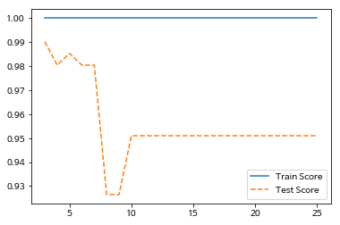

```python
# Train/Test Score 저장할 list
train_accuracy = []; test_accuracy = []

# max_depth
para_depth = [depth for depth in range(3, 26)]


for v_max_depth in para_depth:
    gb = GBC(random_state=1234,
             learning_rate = gb_params['learning_rate'],
             n_estimators = gb_params['n_estimators'],
             max_depth = v_max_depth)
    gb.fit(df_train_x, df_train_y)
    train_accuracy.append(gb.score(df_train_x, df_train_y))
    test_accuracy.append(gb.score(df_valid_x, df_valid_y))


df_score_depth = pd.DataFrame({'Depth': para_depth,
                             'TrainScore': train_accuracy,
                             'TestScore': test_accuracy})

plt.plot(para_depth, train_accuracy, linestyle='-', label="Train Score")
plt.plot(para_depth, test_accuracy, linestyle='--', label="Test Score")
plt.legend()

df_score_depth.sort_values('TestScore', ascending = False).round(3)
```

#### max_depth = 3

```python
## max_depth
gb_params['max_depth'] = 3
```

### min_samples_leaf

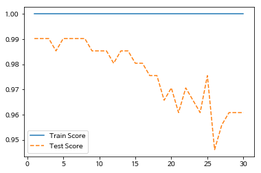

```python
# Train/Test Score 저장할 list
train_accuracy = []; test_accuracy = []

# max_depth
para_leaf = [leaf for leaf in range(1, 31)]


for v_leaf in para_leaf:
    gb = GBC(random_state=1234,
             learning_rate = gb_params['learning_rate'],
             n_estimators = gb_params['n_estimators'],
             max_depth = gb_params['max_depth'],
              min_samples_leaf = v_leaf)
    gb.fit(df_train_x, df_train_y)
    train_accuracy.append(gb.score(df_train_x, df_train_y))
    test_accuracy.append(gb.score(df_valid_x, df_valid_y))


df_score_leaf = pd.DataFrame({'MinleafSize': para_leaf,
                             'TrainScore': train_accuracy,
                             'TestScore': test_accuracy})


plt.plot(para_leaf, train_accuracy, linestyle='-', label="Train Score")
plt.plot(para_leaf, test_accuracy, linestyle='--', label="Test Score")
plt.legend()
```

```python
df_score_leaf.sort_values('TestScore',ascending=False).round(3)
```

|  | MinleafSize | TrainScore | TestScore |
| --- | --- | --- | --- |
| 0 | 1 | 1.0 | 0.990 |
| 2 | 3 | 1.0 | 0.990 |
| 4 | 5 | 1.0 | 0.990 |
| 5 | 6 | 1.0 | 0.990 |
| 6 | 7 | 1.0 | 0.990 |
| 7 | 8 | 1.0 | 0.990 |
| 1 | 2 | 1.0 | 0.990 |
| 3 | 4 | 1.0 | 0.985 |
| 8 | 9 | 1.0 | 0.985 |
| 9 | 10 | 1.0 | 0.985 |
| 10 | 11 | 1.0 | 0.985 |
| 12 | 13 | 1.0 | 0.985 |
| 13 | 14 | 1.0 | 0.985 |
| 14 | 15 | 1.0 | 0.980 |
| 15 | 16 | 1.0 | 0.980 |
| 11 | 12 | 1.0 | 0.980 |
| 16 | 17 | 1.0 | 0.975 |
| 17 | 18 | 1.0 | 0.975 |
| 24 | 25 | 1.0 | 0.975 |
| 19 | 20 | 1.0 | 0.971 |
| 21 | 22 | 1.0 | 0.971 |
| 18 | 19 | 1.0 | 0.966 |
| 22 | 23 | 1.0 | 0.966 |
| 20 | 21 | 1.0 | 0.961 |
| 23 | 24 | 1.0 | 0.961 |
| 27 | 28 | 1.0 | 0.961 |
| 28 | 29 | 1.0 | 0.961 |
| 29 | 30 | 1.0 | 0.961 |
| 26 | 27 | 1.0 | 0.956 |
| 25 | 26 | 1.0 | 0.946 |

```python
gb_params['min_samples_leaf'] = 3
```

### min_samples_split

|  | MinsplitSize | TrainScore | TestScore |
| --- | --- | --- | --- |
| 0 | 6 | 1.0 | 0.985 |
| 1 | 8 | 1.0 | 0.980 |
| 2 | 10 | 1.0 | 0.980 |
| 3 | 12 | 1.0 | 0.980 |
| 4 | 14 | 1.0 | 0.980 |
| 5 | 16 | 1.0 | 0.985 |
| 6 | 18 | 1.0 | 0.985 |
| 7 | 20 | 1.0 | 0.985 |

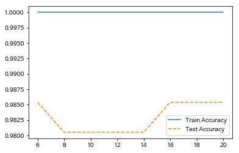

```python
# Train/Test Score 저장할 list
train_accuracy = []; test_accuracy = []

# max_depth
para_split = [split*2 for split in range(3, 11)]


for v_split in para_split:
    gb = GBC(random_state=1234,
             learning_rate = gb_params['learning_rate'],
             n_estimators = gb_params['n_estimators'],
             max_depth = gb_params['max_depth'],
             min_samples_leaf = gb_params['min_samples_leaf'],
             min_samples_split = v_split)
    gb.fit(df_train_x, df_train_y)
    train_accuracy.append(gb.score(df_train_x, df_train_y))
    test_accuracy.append(gb.score(df_test_x, df_test_y))


df_score_split = pd.DataFrame({'MinsplitSize': para_split,
                             'TrainScore': train_accuracy,
                             'TestScore': test_accuracy})


plt.plot(para_split, train_accuracy, linestyle='-', label="Train Accuracy")
plt.plot(para_split, test_accuracy, linestyle='--', label="Test Accuracy")
plt.legend()
df_score_split.round(3)
```

#### min_samples_split = 16

```python
gb_params['min_samples_split'] = 16
```

### 최종 모형

```python
gb_final = GBC(random_state=1234,
               learning_rate = gb_params['learning_rate'],
               n_estimators = gb_params['n_estimators'],
               max_depth = gb_params['max_depth'],
               min_samples_leaf = gb_params['min_samples_leaf'],
               min_samples_split = gb_params['min_samples_split'])
gb_final.fit(df_train_x, df_train_y)
```

```
GradientBoostingClassifier(criterion='friedman_mse', init=None,
              learning_rate=0.35, loss='deviance', max_depth=3,
              max_features=None, max_leaf_nodes=None,
              min_impurity_decrease=0.0, min_impurity_split=None,
              min_samples_leaf=3, min_samples_split=16,
              min_weight_fraction_leaf=0.0, n_estimators=50,
              n_iter_no_change=None, presort='auto', random_state=1234,
              subsample=1.0, tol=0.0001, validation_fraction=0.1,
              verbose=0, warm_start=False)
```

```python
train_final = gb_final.score(df_train_x, df_train_y)
test_final = gb_final.score(df_test_x, df_test_y)
print('TrainScore: {:.3f}\nTestScore: {:.3f}'.format(train_final, test_final))
```

```
TrainScore: 1.000
TestScore: 0.985
```

```python
y_pred = gb_final.predict(df_test_x)
print('Accuracy: {0:.3f}\n'.format(accuracy_score(df_test_y, y_pred)))
print('Confusion Mat:\n{}'.format(confusion_matrix(df_test_y, y_pred)))
```

```
Accuracy: 0.985

Confusion Mat:
[[ 65   3]
 [  0 137]]
```

```python
v_feature_name = df_raw_x.columns
df_importance = pd.DataFrame()
df_importance['Feature'] = v_feature_name
df_importance['Importance'] = gb_final.feature_importances_ # TREECLASS.feature_importances_

df_importance.sort_values('Importance', ascending=False, inplace=True)
df_importance.head(15).round(6)
```

|  | Feature | Importance |
| --- | --- | --- |
| 9 | ROLLING_TEMP_T5 | 0.716368 |
| 6 | FUR_SZ_TEMP | 0.142446 |
| 10 | ROLLING_DESCALING | 0.045699 |
| 0 | PT_THK | 0.041445 |
| 7 | FUR_SZ_TIME | 0.019974 |
| 3 | PT_WGT | 0.011132 |
| 4 | FUR_HZ_TEMP | 0.007255 |
| 8 | FUR_TIME | 0.006484 |
| 19 | WORK_GR_4조 | 0.003577 |
| 1 | PT_WDTH | 0.002720 |
| 30 | SPEC_ABS_KR | 0.001360 |
| 29 | SPEC_ABS_JS | 0.000566 |
| 5 | FUR_HZ_TIME | 0.000463 |
| 39 | STEEL_ABS_T | 0.000334 |
| 38 | STEEL_ABS_C | 0.000178 |

[figure not shown]

```python
plt.figure(figsize=(5,10))
df_importance.sort_values('Importance', ascending=True, inplace=True)
coordinates=range(len(df_importance.tail(10)))
plt.barh(y=coordinates, width=df_importance['Importance'].tail(10))
plt.yticks(coordinates, df_importance['Feature'])
plt.xlabel('변수 중요도')
plt.ylabel('변수')
```

```python
# Train 정확도
train_acc.append(gb_final.score(df_train_x, df_train_y))

# Test 정확도
test_acc.append(gb_final.score(df_test_x, df_test_y))

# 예측값
y_pred = gb_final.predict(df_test_x)

# roc_curve, fpr
fpr, tpr, thresholds = roc_curve(df_test_y, y_pred)
roc_auc = auc(fpr, tpr)

# auc
model_auc.append(roc_auc)

# f1 score
model_f1_score.append(f1_score(df_test_y, y_pred))
```

## 분류 모형별 성능 비교

```python
df_eval = pd.DataFrame(index = model)
df_eval['TrainAccuracy'] = train_acc
df_eval['TestAccuracy'] = test_acc
df_eval['F1Score'] = model_f1_score
df_eval['AUC'] = model_auc
df_eval.round(3)
```

|  | TrainAccuracy | TestAccuracy | F1Score | AUC |
| --- | --- | --- | --- | --- |
| RFC | 0.945 | 0.927 | 0.948 | 0.890 |
| GBC | 1.000 | 0.985 | 0.989 | 0.978 |

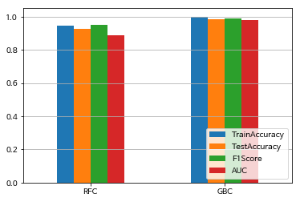

```python
df_eval.plot.bar(rot=0)
plt.legend(loc='lower right') # legend 위치
plt.grid(axis='y')
```

```python
cols_vf = ['ROLLING_TEMP_T5', 'ROLLING_DESCALING', 'FUR_SZ_TEMP', 'FUR_HZ_TEMP', 'FUR_SZ_TIME']
```

# Vital Few로 분류 예측

## 연속 변수 변환

```python
df_cont.head()
```

|  | PT_THK | PT_WDTH | PT_LTH | PT_WGT | FUR_HZ_TEMP | FUR_HZ_TIME | FUR_SZ_TEMP | FUR_SZ_TIME | FUR_TIME | ROLLING_TEMP_T5 | SCALE |
| --- | --- | --- | --- | --- | --- | --- | --- | --- | --- | --- | --- |
| 0 | 32.25 | 3707 | 15109 | 14180 | 1144 | 116 | 1133 | 59 | 282 | 934 | 양품 |
| 1 | 32.25 | 3707 | 15109 | 14180 | 1144 | 122 | 1135 | 53 | 283 | 937 | 양품 |
| 2 | 33.27 | 3619 | 19181 | 18130 | 1129 | 116 | 1121 | 55 | 282 | 889 | 양품 |
| 3 | 33.27 | 3619 | 19181 | 18130 | 1152 | 125 | 1127 | 68 | 316 | 885 | 양품 |
| 4 | 38.33 | 3098 | 13334 | 12430 | 1140 | 134 | 1128 | 48 | 314 | 873 | 양품 |

```python
scaler = StandardScaler()
df_scaled_x = scaler.fit_transform(df_cont.drop('SCALE', axis = 1))
df_scaled_x = pd.DataFrame(df_scaled_x, columns = df_cont.drop('SCALE', axis = 1).columns)
df_scaled_x.info()
```

```
<class 'pandas.core.frame.DataFrame'>
RangeIndex: 681 entries, 0 to 680
Data columns (total 10 columns):
PT_THK             681 non-null float64
PT_WDTH            681 non-null float64
PT_LTH             681 non-null float64
PT_WGT             681 non-null float64
FUR_HZ_TEMP        681 non-null float64
FUR_HZ_TIME        681 non-null float64
FUR_SZ_TEMP        681 non-null float64
FUR_SZ_TIME        681 non-null float64
FUR_TIME           681 non-null float64
ROLLING_TEMP_T5    681 non-null float64
dtypes: float64(10)
memory usage: 53.3 KB
```

```python
df_svm_x = df_raw_x
df_svm_x.info()
```

```
<class 'pandas.core.frame.DataFrame'>
Int64Index: 681 entries, 0 to 719
Data columns (total 41 columns):
PT_THK               644 non-null float64
PT_WDTH              644 non-null float64
PT_LTH               644 non-null float64
PT_WGT               644 non-null float64
FUR_HZ_TEMP          644 non-null float64
FUR_HZ_TIME          644 non-null float64
FUR_SZ_TEMP          644 non-null float64
FUR_SZ_TIME          644 non-null float64
FUR_TIME             644 non-null float64
ROLLING_TEMP_T5      644 non-null float64
ROLLING_DESCALING    681 non-null int64
FUR_NO_1호기           681 non-null uint8
FUR_NO_2호기           681 non-null uint8
FUR_NO_3호기           681 non-null uint8
FUR_NO_ROW_1         681 non-null uint8
FUR_NO_ROW_2         681 non-null uint8
WORK_GR_1조           681 non-null uint8
WORK_GR_2조           681 non-null uint8
WORK_GR_3조           681 non-null uint8
WORK_GR_4조           681 non-null uint8
SPEC_ABS_A28         681 non-null uint8
SPEC_ABS_A51         681 non-null uint8
SPEC_ABS_A70         681 non-null uint8
SPEC_ABS_AB          681 non-null uint8
SPEC_ABS_API         681 non-null uint8
SPEC_ABS_BV          681 non-null uint8
SPEC_ABS_CCS         681 non-null uint8
SPEC_ABS_COM         681 non-null uint8
SPEC_ABS_GL          681 non-null uint8
SPEC_ABS_JS          681 non-null uint8
SPEC_ABS_KR          681 non-null uint8
SPEC_ABS_KS          681 non-null uint8
SPEC_ABS_LR          681 non-null uint8
SPEC_ABS_NK          681 non-null uint8
SPEC_ABS_NV          681 non-null uint8
SPEC_ABS_PIL         681 non-null uint8
SPEC_ABS_SA2         681 non-null uint8
SPEC_ABS_V42         681 non-null uint8
STEEL_ABS_C          681 non-null uint8
STEEL_ABS_T          681 non-null uint8
na                   681 non-null bool
dtypes: bool(1), float64(10), int64(1), uint8(29)
memory usage: 103.8 KB
```

```python
var_list = df_raw_x.columns

i = 0
for col in var_list:
    if i <= 9:
        df_svm_x[col] = df_scaled_x[col]
        i = i + 1
    else:
        break
```

```python
df_svm_x.info()
```

```
<class 'pandas.core.frame.DataFrame'>
Int64Index: 681 entries, 0 to 719
Data columns (total 41 columns):
PT_THK               644 non-null float64
PT_WDTH              644 non-null float64
PT_LTH               644 non-null float64
PT_WGT               644 non-null float64
FUR_HZ_TEMP          644 non-null float64
FUR_HZ_TIME          644 non-null float64
FUR_SZ_TEMP          644 non-null float64
FUR_SZ_TIME          644 non-null float64
FUR_TIME             644 non-null float64
ROLLING_TEMP_T5      644 non-null float64
ROLLING_DESCALING    681 non-null int64
FUR_NO_1호기           681 non-null uint8
FUR_NO_2호기           681 non-null uint8
FUR_NO_3호기           681 non-null uint8
FUR_NO_ROW_1         681 non-null uint8
FUR_NO_ROW_2         681 non-null uint8
WORK_GR_1조           681 non-null uint8
WORK_GR_2조           681 non-null uint8
WORK_GR_3조           681 non-null uint8
WORK_GR_4조           681 non-null uint8
SPEC_ABS_A28         681 non-null uint8
SPEC_ABS_A51         681 non-null uint8
SPEC_ABS_A70         681 non-null uint8
SPEC_ABS_AB          681 non-null uint8
SPEC_ABS_API         681 non-null uint8
SPEC_ABS_BV          681 non-null uint8
SPEC_ABS_CCS         681 non-null uint8
SPEC_ABS_COM         681 non-null uint8
SPEC_ABS_GL          681 non-null uint8
SPEC_ABS_JS          681 non-null uint8
SPEC_ABS_KR          681 non-null uint8
SPEC_ABS_KS          681 non-null uint8
SPEC_ABS_LR          681 non-null uint8
SPEC_ABS_NK          681 non-null uint8
SPEC_ABS_NV          681 non-null uint8
SPEC_ABS_PIL         681 non-null uint8
SPEC_ABS_SA2         681 non-null uint8
SPEC_ABS_V42         681 non-null uint8
STEEL_ABS_C          681 non-null uint8
STEEL_ABS_T          681 non-null uint8
na                   681 non-null bool
dtypes: bool(1), float64(10), int64(1), uint8(29)
memory usage: 103.8 KB
```

```python
list_na = df_svm_x['PT_THK'].isna()
list_na.tail(10)
```

```
671    False
672    False
673    False
674    False
675    False
676    False
677    False
678    False
679    False
680    False
Name: PT_THK, dtype: bool
```

```python
df_svm_x['na'] = list_na
df_svm_y = df_raw_y
df_svm_y['na'] = list_na
```

```python
df_svm_x = df_svm_x.query('na==False')
df_svm_x.drop(columns='na', inplace=True)
df_svm_y = df_svm_y.query('na==False')
df_svm_y.drop(columns='na', inplace=True)
```

### Vital Few 적합

```python
df_svm_x.info()
```

```
<class 'pandas.core.frame.DataFrame'>
Int64Index: 644 entries, 0 to 680
Data columns (total 40 columns):
PT_THK               644 non-null float64
PT_WDTH              644 non-null float64
PT_LTH               644 non-null float64
PT_WGT               644 non-null float64
FUR_HZ_TEMP          644 non-null float64
FUR_HZ_TIME          644 non-null float64
FUR_SZ_TEMP          644 non-null float64
FUR_SZ_TIME          644 non-null float64
FUR_TIME             644 non-null float64
ROLLING_TEMP_T5      644 non-null float64
ROLLING_DESCALING    644 non-null int64
FUR_NO_1호기           644 non-null uint8
FUR_NO_2호기           644 non-null uint8
FUR_NO_3호기           644 non-null uint8
FUR_NO_ROW_1         644 non-null uint8
FUR_NO_ROW_2         644 non-null uint8
WORK_GR_1조           644 non-null uint8
WORK_GR_2조           644 non-null uint8
WORK_GR_3조           644 non-null uint8
WORK_GR_4조           644 non-null uint8
SPEC_ABS_A28         644 non-null uint8
SPEC_ABS_A51         644 non-null uint8
SPEC_ABS_A70         644 non-null uint8
SPEC_ABS_AB          644 non-null uint8
SPEC_ABS_API         644 non-null uint8
SPEC_ABS_BV          644 non-null uint8
SPEC_ABS_CCS         644 non-null uint8
SPEC_ABS_COM         644 non-null uint8
SPEC_ABS_GL          644 non-null uint8
SPEC_ABS_JS          644 non-null uint8
SPEC_ABS_KR          644 non-null uint8
SPEC_ABS_KS          644 non-null uint8
SPEC_ABS_LR          644 non-null uint8
SPEC_ABS_NK          644 non-null uint8
SPEC_ABS_NV          644 non-null uint8
SPEC_ABS_PIL         644 non-null uint8
SPEC_ABS_SA2         644 non-null uint8
SPEC_ABS_V42         644 non-null uint8
STEEL_ABS_C          644 non-null uint8
STEEL_ABS_T          644 non-null uint8
dtypes: float64(10), int64(1), uint8(29)
memory usage: 78.6 KB
```

```python
df_vf_x = df_scaled_x[['FUR_SZ_TEMP', 'FUR_SZ_TIME', 'FUR_HZ_TEMP',
                   'ROLLING_TEMP_T5']]
```

```python
df_vf_x['ROLLING_DESCALING'] = df_raw['ROLLING_DESCALING']
```

```python
df_vf_x.info()
```

```
<class 'pandas.core.frame.DataFrame'>
RangeIndex: 681 entries, 0 to 680
Data columns (total 5 columns):
FUR_SZ_TEMP          681 non-null float64
FUR_SZ_TIME          681 non-null float64
FUR_HZ_TEMP          681 non-null float64
ROLLING_TEMP_T5      681 non-null float64
ROLLING_DESCALING    681 non-null int64
dtypes: float64(4), int64(1)
memory usage: 26.7 KB
```

```python
df_svm_y = pd.get_dummies(df_raw_y, drop_first = True)
```

```python
df_svm_train_x, df_svm_test_x, df_svm_train_y, df_svm_test_y = train_test_split(df_vf_x, df_svm_y, test_size = 0.3, random_state=1234)
print('train data X size:{}'.format(df_svm_train_x.shape))
print('train data Y size:{}'.format(df_svm_train_y.shape))
print('test data X size:{}'.format(df_svm_test_x.shape))
print('test data Y size:{}'.format(df_svm_test_y.shape))
```

```
train data X size:(476, 5)
train data Y size:(476, 1)
test data X size:(205, 5)
test data Y size:(205, 1)
```

## 서포트 벡터 머신 GridSearch

```python
estimator = SVC(random_state=1234)
```

```python
para_c = [C/10 for C in range(1,101)]
para_gamma = [gamma/10 for gamma in range(1,101)]
param_grid = {"C":para_c, "gamma":para_gamma}

grid_svm = GridSearchCV(estimator, param_grid, scoring='f1', n_jobs=-1, cv=3)
grid_svm.fit(df_svm_train_x, df_svm_train_y)
print('Best Estimator Model: \n{}'.format(grid_svm.best_estimator_))
print('\nBest Parameter: \n{}'.format(grid_svm.best_params_))
print('\nBest Score: \n{}'.format(grid_svm.best_score_.round(3)))
```

```
Best Estimator Model:
SVC(C=7.3, cache_size=200, class_weight=None, coef0=0.0,
  decision_function_shape='ovr', degree=3, gamma=0.2, kernel='rbf',
  max_iter=-1, probability=False, random_state=1234, shrinking=True,
  tol=0.001, verbose=False)

Best Parameter:
{'C': 7.3, 'gamma': 0.2}

Best Score:
0.94
```

```python
svm_final = grid_svm.best_estimator_
svm_final.fit(df_svm_test_x, df_svm_test_y)
```

```
SVC(C=7.3, cache_size=200, class_weight=None, coef0=0.0,
  decision_function_shape='ovr', degree=3, gamma=0.2, kernel='rbf',
  max_iter=-1, probability=False, random_state=1234, shrinking=True,
  tol=0.001, verbose=False)
```

```python
train_final = svm_final.score(df_svm_train_x, df_svm_train_y)
test_final = svm_final.score(df_svm_test_x, df_svm_test_y)
print('TrainScore: {:.3f}\nTestScore: {:.3f}'.format(train_final, test_final))
```

```
TrainScore: 0.897
TestScore: 0.932
```

```python
y_pred = svm_final.predict(df_svm_test_x)
print('Accuracy: {0:.3f}\n'.format(accuracy_score(df_svm_test_y, y_pred)))
print('Confusion Mat:\n{}'.format(confusion_matrix(df_svm_test_y, y_pred)))
```

```
Accuracy: 0.932

Confusion Mat:
[[ 57  11]
 [  3 134]]
```

## 의사결정 나무 GridSearch

```python
df_raw.info()
```

```
<class 'pandas.core.frame.DataFrame'>
Int64Index: 681 entries, 0 to 719
Data columns (total 19 columns):
SCALE                681 non-null object
SPEC                 681 non-null object
STEEL_KIND           681 non-null object
PT_THK               681 non-null float64
PT_WDTH              681 non-null int64
PT_LTH               681 non-null int64
PT_WGT               681 non-null int64
FUR_NO               681 non-null object
FUR_NO_ROW           681 non-null object
FUR_HZ_TEMP          681 non-null int64
FUR_HZ_TIME          681 non-null int64
FUR_SZ_TEMP          681 non-null int64
FUR_SZ_TIME          681 non-null int64
FUR_TIME             681 non-null int64
ROLLING_TEMP_T5      681 non-null int64
ROLLING_DESCALING    681 non-null int64
WORK_GR              681 non-null object
SPEC_ABS             681 non-null object
STEEL_ABS            681 non-null object
dtypes: float64(1), int64(10), object(8)
memory usage: 126.4+ KB
```

```python
df_tree_x = df_raw[['FUR_SZ_TEMP', 'FUR_SZ_TIME', 'FUR_HZ_TEMP',
                   'ROLLING_TEMP_T5', 'ROLLING_DESCALING']]
df_tree_y = pd.get_dummies(df_raw[['SCALE']], drop_first = True)
```

```python
df_tree_x.describe().round(3)
```

|  | FUR_SZ_TEMP | FUR_SZ_TIME | FUR_HZ_TEMP | ROLLING_TEMP_T5 | ROLLING_DESCALING |
| --- | --- | --- | --- | --- | --- |
| count | 681.000 | 681.000 | 681.000 | 681.000 | 681.000 |
| mean | 1149.630 | 78.843 | 1155.301 | 942.311 | 8.317 |
| std | 17.474 | 36.634 | 20.796 | 66.127 | 1.612 |
| min | 1113.000 | 35.000 | 1103.000 | 723.000 | 5.000 |
| 25% | 1133.000 | 57.000 | 1139.000 | 891.000 | 7.000 |
| 50% | 1155.000 | 68.000 | 1158.000 | 953.000 | 8.000 |
| 75% | 1164.000 | 86.000 | 1171.000 | 996.000 | 10.000 |
| max | 1185.000 | 294.000 | 1206.000 | 1078.000 | 10.000 |

```python
df_tree_train_x, df_tree_test_x, df_tree_train_y, df_tree_test_y = train_test_split(df_tree_x, df_tree_y, test_size = 0.3, random_state=1234)
print('train data X size:{}'.format(df_tree_train_x.shape))
print('train data Y size:{}'.format(df_tree_train_y.shape))
print('test data X size:{}'.format(df_tree_test_x.shape))
print('test data Y size:{}'.format(df_tree_test_y.shape))
```

```
train data X size:(476, 5)
train data Y size:(476, 1)
test data X size:(205, 5)
test data Y size:(205, 1)
```

```python
tree_final = DTC(random_state = 1234)
tree_final
```

```
DecisionTreeClassifier(class_weight=None, criterion='gini', max_depth=None,
            max_features=None, max_leaf_nodes=None,
            min_impurity_decrease=0.0, min_impurity_split=None,
            min_samples_leaf=1, min_samples_split=2,
            min_weight_fraction_leaf=0.0, presort=False, random_state=1234,
            splitter='best')
```

```python
para_criterion = ['gini', 'entropy']
para_depth = [depth for depth in range(3,11)]
para_leaf = [leaf for leaf in range(3,11)]
para_split = [split*2 for split in range(3,11)]
param_grid = {'criterion': para_criterion,
             'max_depth': para_depth,
             'min_samples_leaf': para_leaf,
             'min_samples_split': para_split}

grid_tree = GridSearchCV(tree_final, param_grid, scoring='accuracy', n_jobs=-1, cv=3)
grid_tree.fit(df_tree_train_x, df_tree_train_y)
print('Best Estimator Model: \n{}'.format(grid_tree.best_estimator_))
print('\nBest Parameter: \n{}'.format(grid_tree.best_params_))
print('\nBest Score: \n{}'.format(grid_tree.best_score_.round(3)))
```

```
Best Estimator Model:
DecisionTreeClassifier(class_weight=None, criterion='entropy', max_depth=7,
            max_features=None, max_leaf_nodes=None,
            min_impurity_decrease=0.0, min_impurity_split=None,
            min_samples_leaf=3, min_samples_split=6,
            min_weight_fraction_leaf=0.0, presort=False, random_state=1234,
            splitter='best')

Best Parameter:
{'criterion': 'entropy', 'max_depth': 7, 'min_samples_leaf': 3, 'min_samples_split': 6}

Best Score:
0.987
```

```python
final_tree = DTC(criterion = 'gini',
                max_depth = 3,
                min_samples_leaf = 3,
                min_samples_split = 6)
final_tree.fit(df_tree_train_x, df_tree_train_y)
export_graphviz(final_tree, out_file='tree_leaf.dot',
               feature_names=df_tree_train_x.columns, impurity=True, filled=True,
               class_names=['불량','양품'])
with open('tree_leaf.dot') as f:
    dot_graph = f.read()

display(graphviz.Source(dot_graph))
```

[figure not shown]

```python
y_pred = final_tree.predict(df_tree_test_x)
print('Accuracy: {0:.3f}\n'.format(accuracy_score(df_tree_test_y, y_pred)))
print('Confusion Mat:\n{}'.format(confusion_matrix(df_tree_test_y, y_pred)))
```

```
Accuracy: 0.951

Confusion Mat:
[[ 58  10]
 [  0 137]]
```